# SAP Projekt

Statistički Analizirani

2025-12-10

### Motivacija i opis problema

Moždani udar je hitno medicinsko stanje koje nastaje nakon poremećaja cirkulacije u mozgu. U Hrvatskoj je drugi najveći uzrok smrti te prvi najveći uzrok invaliditeta. Rizik od moždanog udara kod pojedine osobe može ovisiti o više faktora pa se u medicini koriste razni modeli za njegovu procjenu. Nije strana ni uporaba alata zasnovanih na umjernoj inteligenciji. Predikcija moždanog udara bitna je za pravovremenu identifikaciju rizika koje omogućava pravovremene mjere prevencije i osvještavanje populacije.

### Opis skupa podataka

Prikupljeni skup podataka sadrži kliničke podatke o pacijentima i informacije o moždanom udaru. Za svakog pacijenta navedena je vrijednost 12 značajki grupiranih u 4 kategorije: demografski podaci, zdravstveni podaci, fiziološki podaci i životne navike. Cilj je uočiti povezanost izmjerenih podataka i rizika od moždanog udara. Skup podataka sadržava 5,110 zapisa o pacijentima od kojih je njih 249 doživjelo moždani udar. Udio pacijenata koji su doživjeli moždani udar iznosi 4.87%

- id: jedinstveni identifikator pacijenta
- gender: spol pacijenta (Male, Female)
- age: dob pacijenta
- hypertension: oznaka koja daje informaciju o tome ima li pacijent visoki tlak (0, 1)
- heart_disease: oznaka koja daje informaciju ima li pacijent neku srčanu bolest (0, 1)
- ever_married: odgovara na pitanje je li pacijent ikad bio u braku (No, Yes) work_type: tip zaposlenja (children, Govt_job, Never_worked, Private, Self-employed)
- Residence_type: tip prebivališta u kojem živi pacijent (Rural, Urban)
- avg_glucose_lvl: prosječna razina glukoze u krvi (mg/dL)
- bmi: indeks tjelesne mase koji predstavlja odnos visine i težine pacijenta
- smoking_status: opis pacijentovog odnosa s pušenjem cigareta (formerly smoked, never smoked, smokes, Unknown)
- stroke: oznaka koja daje informaciju je li pacijent doživio moždani udar (0, 1)

### Učitavanje i pregled podataka

```r
data <- read.csv("data.csv")
head(data)
```

|  | id | gender | age | hypertension | heart_disease | ever_married | work_type | Residence_type | avg_glucose_level | bmi | smoking_status | stroke |
| --- | --- | --- | --- | --- | --- | --- | --- | --- | --- | --- | --- | --- |
| 1 | 9046 | Male | 67 | 0 | 1 | Yes | Private | Urban | 228.69 | 36.6 | formerly smoked | 1 |
| 2 | 51676 | Female | 61 | 0 | 0 | Yes | Self-employed | Rural | 202.21 | N/A | never smoked | 1 |
| 3 | 31112 | Male | 80 | 0 | 1 | Yes | Private | Rural | 105.92 | 32.5 | never smoked | 1 |
| 4 | 60182 | Female | 49 | 0 | 0 | Yes | Private | Urban | 171.23 | 34.4 | smokes | 1 |
| 5 | 1665 | Female | 79 | 1 | 0 | Yes | Self-employed | Rural | 174.12 | 24 | never smoked | 1 |
| 6 | 56669 | Male | 81 | 0 | 0 | Yes | Private | Urban | 186.21 | 29 | formerly smoked | 1 |

```r
str(data)
```

```
## 'data.frame':    5110 obs. of  12 variables:
##  $ id               : int  9046 51676 31112 60182 1665 56669 53882 10434 27419 60491 ...
##  $ gender           : chr  "Male" "Female" "Male" "Female" ...
##  $ age              : num  67 61 80 49 79 81 74 69 59 78 ...
##  $ hypertension     : int  0 0 0 0 1 0 1 0 0 0 ...
##  $ heart_disease    : int  1 0 1 0 0 0 1 0 0 0 ...
##  $ ever_married     : chr  "Yes" "Yes" "Yes" "Yes" ...
##  $ work_type        : chr  "Private" "Self-employed" "Private" "Private" ...
##  $ Residence_type   : chr  "Urban" "Rural" "Rural" "Urban" ...
##  $ avg_glucose_level: num  229 202 106 171 174 ...
##  $ bmi              : chr  "36.6" "N/A" "32.5" "34.4" ...
##  $ smoking_status   : chr  "formerly smoked" "never smoked" "never smoked" "smokes" ...
##  $ stroke           : int  1 1 1 1 1 1 1 1 1 1 ...
```

Iz generiranih prikaza moguće je vidjeti neke od vrijednosti koje poprimaju pojedini atributi vezani uz pacijenta, ali i tip podataka koji prikazuju. Primjetljivo je kako se atribut bmi vodi kao niz znakova iako semantički predstavlja decimalni broj. Pri izradi dijagrama i u budućim računima potrebno je pripaziti da se bmi ne prikaže kao kategorični atribut.

#### Prikaz demografskih podataka

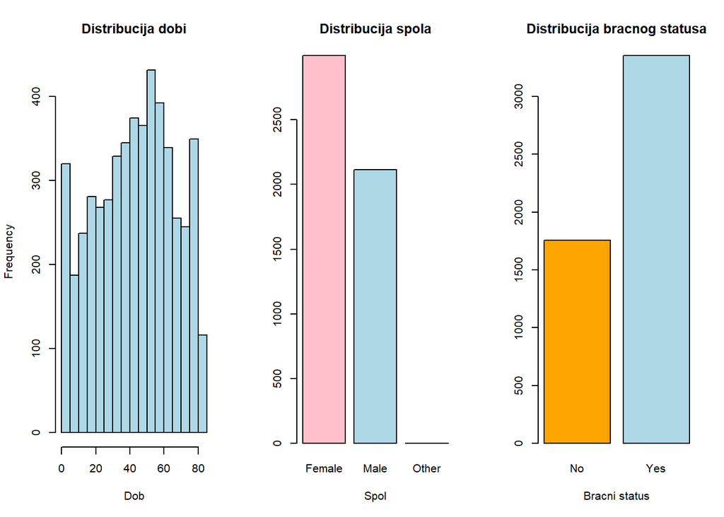

```r
par(mfrow = c(1,3))
hist(data$age , main = "Distribucija dobi", xlab = "Dob", col = "lightblue", border = "black")
barplot(table(data$gender), main = "Distribucija spola", xlab = "Spol", col = c("pink","lightblue","black"),border="black")
barplot(table(data$ever_married), main = "Distribucija bracnog statusa", xlab = "Bracni status", col = c("orange","lightblue"),border="black")
```

```r
summary(data$age)
```

```
##    Min. 1st Qu.  Median    Mean 3rd Qu.    Max.
##    0.08   25.00   45.00   43.23   61.00   82.00
```

```r
prop.table(table(data$gender, useNA = "ifany"))
```

```
##
##       Female         Male        Other
## 0.5859099804 0.4138943249 0.0001956947
```

```r
prop.table(table(data$ever_married, useNA = "ifany"))
```

```
##
##        No       Yes
## 0.3438356 0.6561644
```

Distribucija dobi ispitanika blago je zakrivljena u lijevo. Prosječan broj godina pacijenta iznosi 43.23 godine, a njihov raspon je razlika između 82 godine i 0.08 godina. Dakle, zastupljene su gotovo sve dobne skupine te nema bitnih odstupanja.

Broj ženskih ispitanih pacijenata je neočekivano velik u odnosu na muške ispitanike. Pacijentice zauzimaju čak 58.6% skupa podataka.

Većina ispitanika je u svom životu bar jednom stupila u brak.

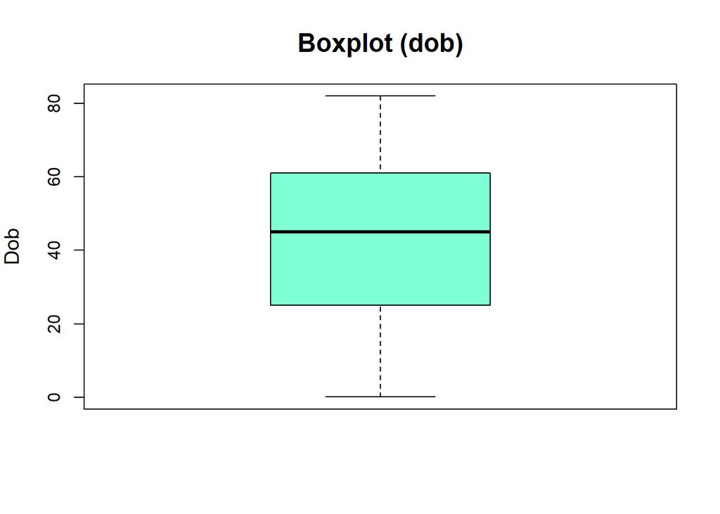

```r
boxplot(data$age,
main = "Boxplot (dob)",
ylab = "Dob",
col = "aquamarine",
cex.main = 1.5, cex.lab = 1.2)
```

#### Prikaz zdravstvenih podataka

Kao što je prethodno navedeno, potrebno je pripremiti atribut bmi.

```r
bmi<-data$bmi

bmi[bmi == "N/A"] <- NA
bmi <- as.numeric(bmi)
```

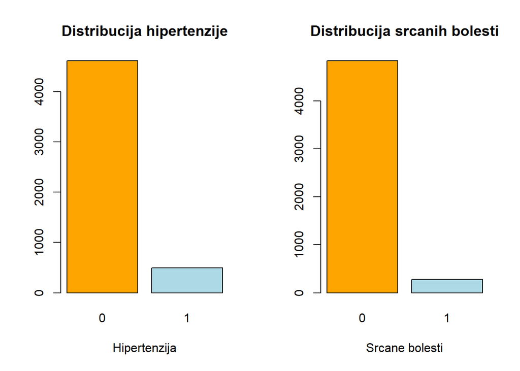

```r
par(mfrow = c(1,2))
barplot(table(data$hypertension), main = "Distribucija hipertenzije", xlab = "Hipertenzija", col = c("orange","lightblue"),border="black")
barplot(table(data$heart_disease), main = "Distribucija srcanih bolesti", xlab = "Srcane bolesti", col = c("orange","lightblue"),border="black")
```

```r
young_with_hypertension <- data[data$age<=median(data$age),]$hypertension
old_with_hypertension <- data[data$age>=median(data$age),]$hypertension

list(
    overall_mean = mean(data$hypertension),
    young_mean   = mean(young_with_hypertension),
    old_mean     = mean(old_with_hypertension)
  )
```

```
## $overall_mean
## [1] 0.09745597
##
## $young_mean
## [1] 0.02444614
##
## $old_mean
## [1] 0.1715173
```

U skupu podataka 9.7% ispitanika ima hipertenziju, međutim ona jako ovisi o dobi ispitanika. Ako uzmemo samo ispitanike starije od medijana skupa, ta brojka postane 17.1%

```r
young_with_heart_disease <- data[data$age<=median(data$age),]$heart_disease
old_with_heart_disease <- data[data$age>=median(data$age),]$heart_disease

list(
    overall_mean = mean(data$heart_disease),
    young_mean   = mean(young_with_heart_disease),
    old_mean     = mean(old_with_heart_disease)
  )
```

```
## $overall_mean
## [1] 0.05401174
##
## $young_mean
## [1] 0.003055768
##
## $old_mean
## [1] 0.1043849
```

Sličan rezultat se dobije i sa srčanim bolestima, gdje u uzorku srčanu bolest ima oko 5.4% dok stariji dio uzorka ima 10.4%

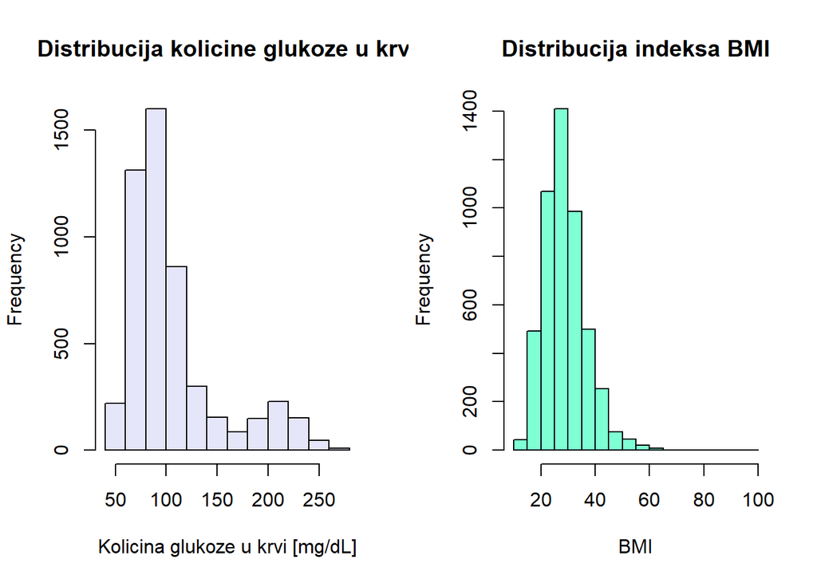

```r
par(mfrow = c(1,2))
hist(data$avg_glucose_level , main = "Distribucija kolicine glukoze u krvi", xlab = "Kolicina glukoze u krvi [mg/dL]", col = "lavender", border = "black")
hist(bmi , main = "Distribucija indeksa BMI", xlab = "BMI", col = "aquamarine", border = "black")
```

```r
summary(data$avg_glucose_level)
```

```
##    Min. 1st Qu.  Median    Mean 3rd Qu.    Max.
##   55.12   77.25   91.89  106.15  114.09  271.74
```

```r
summary(bmi)
```

```
##    Min. 1st Qu.  Median    Mean 3rd Qu.    Max.    NA's
##   10.30   23.50   28.10   28.89   33.10   97.60     201
```

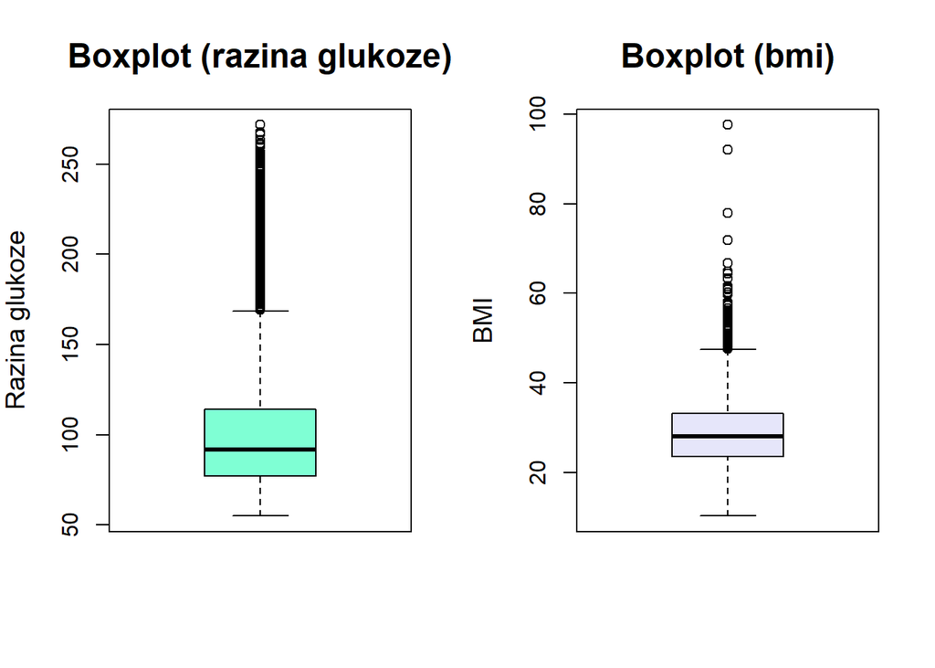

```r
par(mfrow = c(1,2))
boxplot(data$avg_glucose_level,
main = "Boxplot (razina glukoze)",
ylab = "Razina glukoze",
col = "aquamarine",
cex.main = 1.5, cex.lab = 1.2)
boxplot(bmi,
main = "Boxplot (bmi)",
ylab = "BMI",
col = "lavender",
cex.main = 1.5, cex.lab = 1.2)
```

Distribucije atributa vezanih uz razinu glukoze u krvi te BMI imaju sličnost u tome da postoje stršeće vrijednosti. Međutim, razina glukoze krvi je više zakrivljena i to se da očitati iz broja stršećih vrijednosti, ali i pomaka crte medijana u interkvartalnom intervalu.

Nijedna od ove dvije distribucije se ne može smatrati savršeno normalnom.

#### Prikaz podataka o životnim navikama

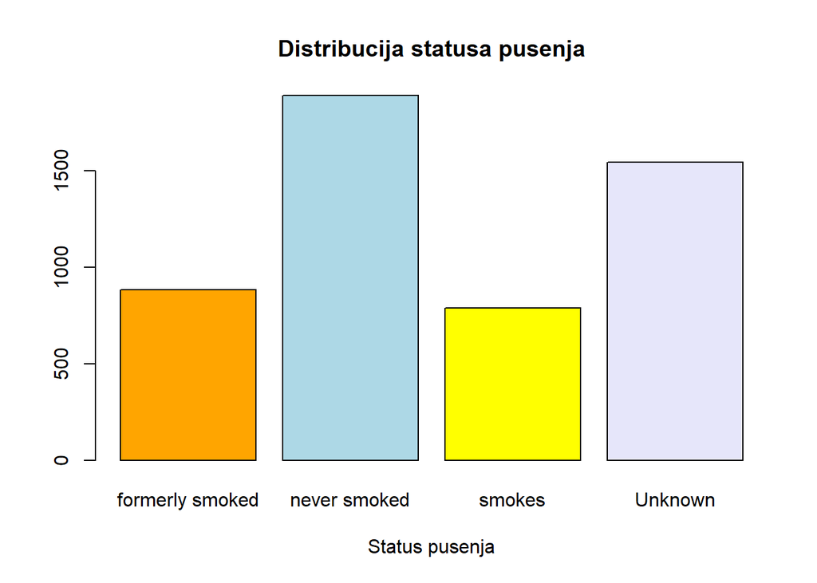

```r
barplot(table(data$smoking_status), main = "Distribucija statusa pusenja", xlab = "Status pusenja", col = c("orange","lightblue","yellow","lavender"),border="black")
```

```r
prop.table(table(data$smoking_status, useNA = "ifany"))
```

```
##
## formerly smoked    never smoked          smokes         Unknown
##       0.1731898       0.3702544       0.1544031       0.3021526
```

Vidljivo je da za veliki postotak ispitanika, čak preko 30%, nemamo informaciju o njihovom statusu pušenja. Važno je napomenuti da se izbacivanjem zapisa o pacijentima sa statusom pušenja “Unknown” zapravo izbacuju gotovo sva djeca iz skupa podataka. Ipak, u skupu pacijenata s “Unknown” statusom pušenja postoje predstavnici gotovo svih dobnih skupina. Sljedeći histogram prikazuje distribuciju dobi “Unknown” pušača.

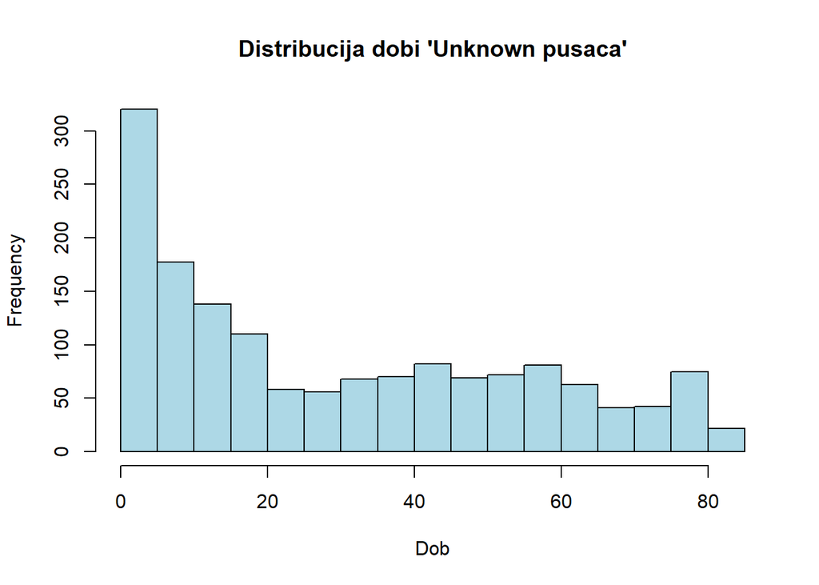

```r
hist(data[data$smoking_status == "Unknown",]$age , main = "Distribucija dobi 'Unknown pusaca'", xlab = "Dob", col = "lightblue", border = "black")
```

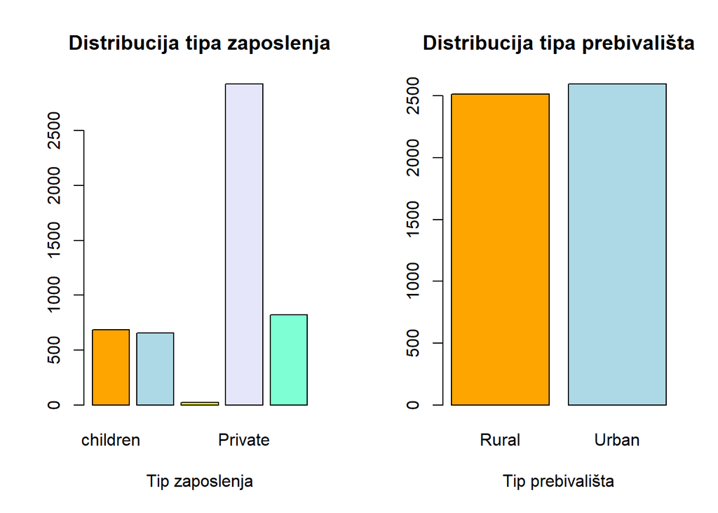

```r
par(mfrow = c(1,2))
barplot(table(data$work_type), main = "Distribucija tipa zaposlenja", xlab = "Tip zaposlenja", col = c("orange","lightblue","yellow","lavender","aquamarine"),border="black")
barplot(table(data$Residence_type), main = "Distribucija tipa prebivališta", xlab = "Tip prebivališta", col = c("orange","lightblue","yellow","lavender"),border="black")
```

```r
prop.table(table(data$work_type, useNA = "ifany"))
```

```
##
##      children      Govt_job  Never_worked       Private Self-employed
##   0.134442270   0.128571429   0.004305284   0.572407045   0.160273973
```

```r
prop.table(table(data$Residence_type, useNA = "ifany"))
```

```
##
##     Rural     Urban
## 0.4919765 0.5080235
```

Većina pacijenata je zaposlena u privatnom sektoru, dok 0,4% njih nikada nije radilo.

Raspodjela između urbane i ruralne sredine u kojoj živi pacijent je gotovo jednolika

```r
mean(data$stroke)
```

```
## [1] 0.04872798
```

U nastavku rada nastojat će se pokazati povezanost opisanih atributa s moždanim udarom. Uz pomoć statističkih testova nastojat će se zaključiti o tome kako i s kolikom uspješnosti je moguće prepoznati rizik od moždanog udara kod pojedine osobe.

### Postoji li statistički značajna razlika u prosječnoj razini glukoze između pacijenata sa i bez moždanog udara?

```r
data_stroke <- data[data$stroke == 1, ]$avg_glucose_level
data_no_stroke <- data[data$stroke == 0,]$avg_glucose_level
summary(data_stroke)
```

```
##    Min. 1st Qu.  Median    Mean 3rd Qu.    Max.
##   56.11   79.79  105.22  132.54  196.71  271.74
```

```r
summary(data_no_stroke)
```

```
##    Min. 1st Qu.  Median    Mean 3rd Qu.    Max.
##   55.12   77.12   91.47  104.80  112.83  267.76
```

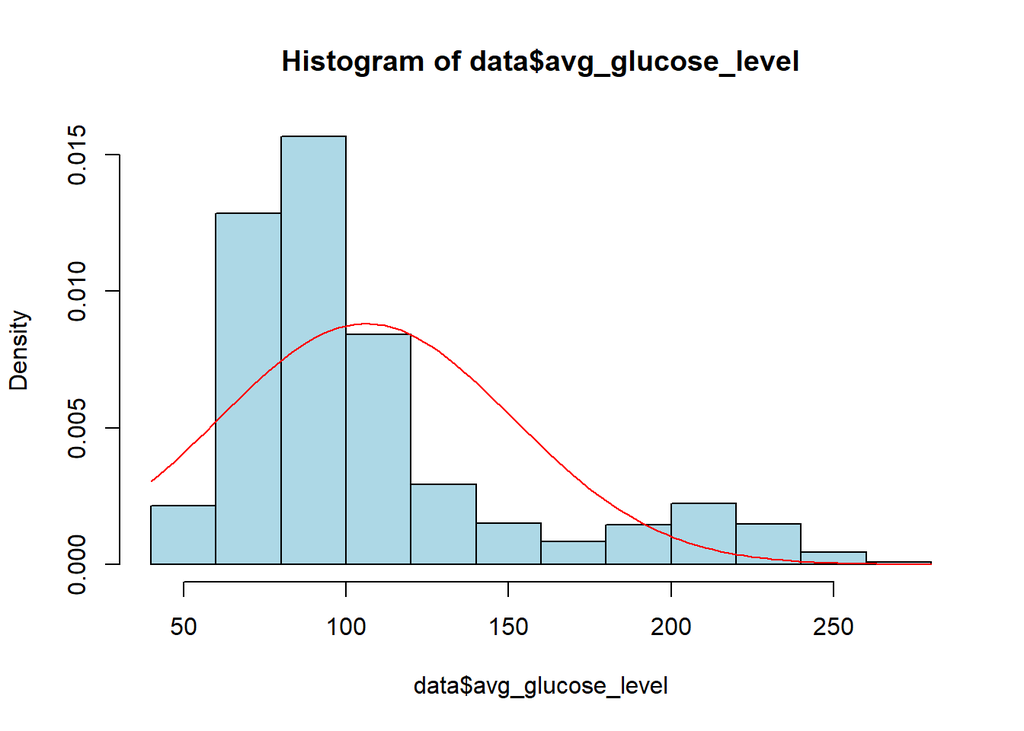

```r
hist(data$avg_glucose_level, freq = FALSE, col = "lightblue", border = "black")
curve(dnorm(x, mean(data$avg_glucose_level), sd(data$avg_glucose_level)), add = TRUE, col = "red")
```

```r
set.seed(67)

B <- 10000

boot_diff <- numeric(B)

for (i in 1:B) {
  boot_data_stroke <- sample(data_stroke, replace = TRUE)
  boot_data_no_stroke <- sample(data_no_stroke, replace = TRUE)
  boot_diff[i] <- mean(boot_data_stroke) - mean(boot_data_no_stroke)
}

# Observed mean difference
obs_diff <- mean(data_stroke) - mean(data_no_stroke)

# 95% bootstrap confidence interval
ci <- quantile(boot_diff, c(0.025, 0.975))

list(
  observed_mean_difference = obs_diff,
  ci_95 = ci
)
```

```
## $observed_mean_difference
## [1] 27.74923
##
## $ci_95
##     2.5%    97.5%
## 19.94809 35.74191
```

```r
head(data)
```

|  | id | gender | age | hypertension | heart_disease | ever_married | work_type | Residence_type | avg_glucose_level | bmi | smoking_status | stroke |
| --- | --- | --- | --- | --- | --- | --- | --- | --- | --- | --- | --- | --- |
| 1 | 9046 | Male | 67 | 0 | 1 | Yes | Private | Urban | 228.69 | 36.6 | formerly smoked | 1 |
| 2 | 51676 | Female | 61 | 0 | 0 | Yes | Self-employed | Rural | 202.21 | N/A | never smoked | 1 |
| 3 | 31112 | Male | 80 | 0 | 1 | Yes | Private | Rural | 105.92 | 32.5 | never smoked | 1 |
| 4 | 60182 | Female | 49 | 0 | 0 | Yes | Private | Urban | 171.23 | 34.4 | smokes | 1 |
| 5 | 1665 | Female | 79 | 1 | 0 | Yes | Self-employed | Rural | 174.12 | 24 | never smoked | 1 |
| 6 | 56669 | Male | 81 | 0 | 0 | Yes | Private | Urban | 186.21 | 29 | formerly smoked | 1 |

### Postoji li interakcijski učinak hipertenzije i srčanih bolesti na BMI?

U ovom istraživačkom pitanju proučavamo ovisi li indeks tjelesne mase (BMI) o prisutnosti hipertenzije i srčanih bolesti te postoji li interakcijski učinak ova dva čimbenika. Dakle, zanima nas utječe li hipertenzija na BMI jednako kod osoba sa i bez srčanih bolesti ili se taj učinak mijenja ovisno o postojanju srčane bolesti. Za potrebe analize koristimo dvostruku analizu varijance s hipertenzijom i srčanim bolestima kao čimbenicima te BMI-jem kao zavisnom varijablom.

## Priprema podataka

Najprije pripremamo podatke. Brišemo nedostajuće vrijednosti BMI-ja, pretvaramo BMI u numeričku varijablu te kodiramo hipertenziju i srčane bolesti kao faktore s dvije razine.

```r
data2 <- read.csv("data.csv", na.strings = "N/A", stringsAsFactors = FALSE)
```

```r
data2$hypertension  <- factor(data2$hypertension, levels = c(0,1), labels = c("no_hypertension","has_hypertension"))
data2$heart_disease <- factor(data2$heart_disease, levels = c(0,1), labels = c("no_heart_disease","has_heart_disease"))


data2$bmi <- as.numeric(data$bmi)
anova_data <- data2[, c("bmi", "hypertension", "heart_disease")]


anova_data <- na.omit(anova_data)


str(anova_data$bmi)
```

```
##  num [1:4909] 36.6 32.5 34.4 24 29 27.4 22.8 24.2 29.7 36.8 ...
```

```r
summary(anova_data$bmi)
```

```
##    Min. 1st Qu.  Median    Mean 3rd Qu.    Max.
##   10.30   23.50   28.10   28.89   33.10   97.60
```

```r
table(anova_data$hypertension, anova_data$heart_disease)
```

```
##
##                    no_heart_disease has_heart_disease
##   no_hypertension              4273               185
##   has_hypertension              393                58
```

Broj opažanja nakon izbacivanja nedostajućih vrijednosti daje nam efektivnu veličinu uzorka za ovu analizu.

Ukupno je u analizi sudjelovalo 4909 ispitanika. Raspodjela prema prisutnosti hipertenzije i srčane bolesti je sljedeća:

- nema hipertenziju, nema srčanu bolest: **87.0 %**
- nema hipertenziju, ima srčanu bolest: **3.8 %**
- ima hipertenziju, nema srčanu bolest: **8.0 %**
- ima hipertenziju, ima srčanu bolest: **1.2 %**

Promatramo li postotke unutar razina hipertenzije:

- među osobama **bez hipertenzije**:
  - 95.9 % **nema** srčanu bolest
  - 4.1 % **ima** srčanu bolest
- među osobama **s hipertenzijom**:
  - 87.1 % **nema** srčanu bolest
  - 12.9 % **ima** srčanu bolest

Promatramo li postotke unutar razina srčane bolesti:

- među osobama **bez srčane bolesti**:
  - 91.6 % **nema** hipertenziju
  - 8.4 % **ima** hipertenziju
- među osobama **sa srčanom bolešću**:
  - 76.1 % **nema** hipertenziju
  - 23.9 % **ima** hipertenziju

```r
head(anova_data)
```

|  | bmi | hypertension | heart_disease |
| --- | --- | --- | --- |
| 1 | 36.6 | no_hypertension | has_heart_disease |
| 3 | 32.5 | no_hypertension | has_heart_disease |
| 4 | 34.4 | no_hypertension | no_heart_disease |
| 5 | 24.0 | has_hypertension | no_heart_disease |
| 6 | 29.0 | no_hypertension | no_heart_disease |
| 7 | 27.4 | has_hypertension | has_heart_disease |

## Sredine po grupama

Najprije izračunavamo prosječne vrijednosti BMI-ja po svakoj kombinaciji hipertenzije i srčane bolesti te ih vizualiziramo.

```r
aggregate(bmi ~ hypertension + heart_disease,
          data = anova_data,
          FUN = mean)
```

| hypertension | heart_disease | bmi |
| --- | --- | --- |
| no_hypertension | no_heart_disease | 28.40875 |
| has_hypertension | no_heart_disease | 33.28092 |
| no_hypertension | has_heart_disease | 29.98270 |
| has_hypertension | has_heart_disease | 31.38103 |

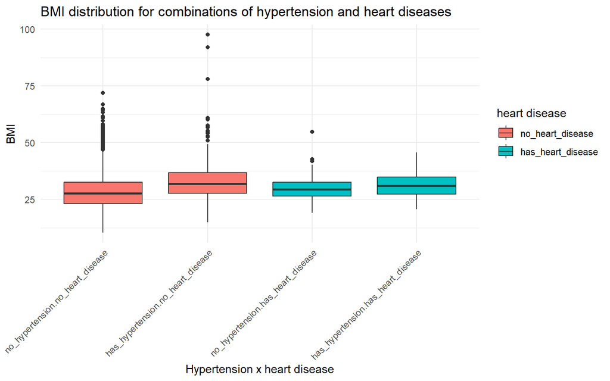

```r
ggplot(anova_data,
       aes(x = interaction(hypertension, heart_disease),
           y = bmi,
           fill = heart_disease)) +
  geom_boxplot() +
  labs(x = "Hypertension x heart disease",
       y = "BMI",
       fill = "heart disease",
       title = "BMI distribution for combinations of hypertension and heart diseases") +
  theme_minimal() +
  theme(axis.text.x = element_text(angle = 45, hjust = 1))
```

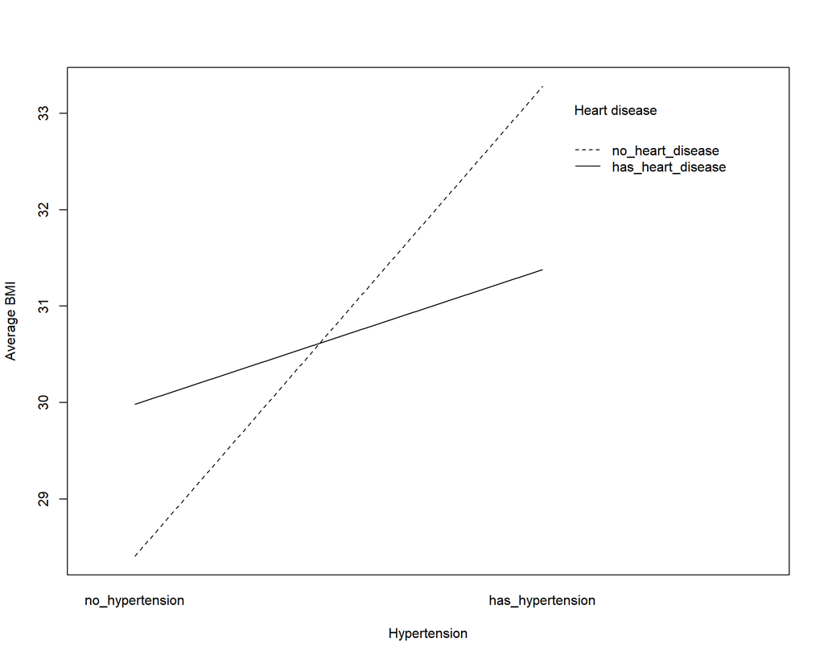

```r
with(anova_data,
     interaction.plot(hypertension, heart_disease, bmi,
                      fun = mean,
                      xlab = "Hypertension",
                      ylab = "Average BMI",
                      trace.label = "Heart disease"))
```

Iz tablice sredina i grafova vidimo kako se prosječni BMI razlikuje između grupa. Zbog toga nas zanima mijenja li se razlika u BMI-ju između osoba s i bez hipertenzije ovisno o tome imaju li srčanu bolest, što je indikacija mogućeg interakcijskog učinka.

## Dvostruka ANOVA s interakcijom: formulacija hipoteza i primjena testa

Glavni učinak hipertenzije:

- H0: prosječni BMI je jednak kod osoba sa i bez hipertenzije
- H1: prosječni BMI se razlikuje između osoba sa i bez hipertenzije

Glavni učinak srčanih bolesti:

- H0: prosječni BMI je jednak kod osoba sa i bez srčane bolesti
- H1: prosječni BMI se razlikuje između osoba sa i bez srčane bolesti

Interakcijski učinak:

- H0: nema interakcijskog učinka hipertenzije i srčanih bolesti na BMI
- H1: postoji interakcijski učinak hipertenzije i srčanih bolesti na BMI

Za testiranje hipoteza koristimo dvostruku ANOVA-u s interakcijom:

```r
test_anova <- aov(bmi ~ hypertension * heart_disease, data = anova_data)
summary(test_anova)
```

```
##                              Df Sum Sq Mean Sq F value  Pr(>F)
## hypertension                  1   8526    8526 142.430 < 2e-16 ***
## heart_disease                 1    147     147   2.457 0.11705
## hypertension:heart_disease    1    475     475   7.929 0.00488 **
## Residuals                  4905 293609      60
## ---
## Signif. codes:  0 '***' 0.001 '**' 0.01 '*' 0.05 '.' 0.1 ' ' 1
```

## Provjera pretpostavki

Analiza varijance pretpostavlja približnu normalnost reziduala i sličnost varijanci između grupa.

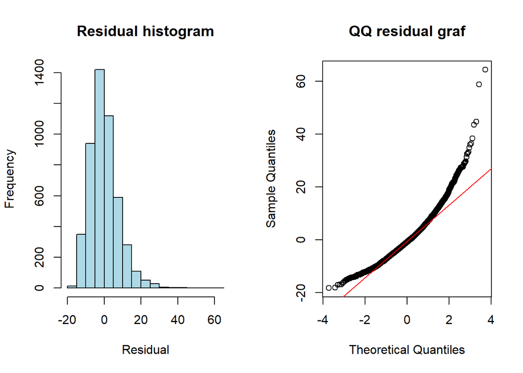

```r
rezid <- residuals(test_anova)

par(mfrow = c(1, 2))
hist(rezid, main = "Residual histogram", xlab = "Residual", col = "lightblue", border = "black")
qqnorm(rezid, main = "QQ residual graf")
qqline(rezid, col = "red")
```

```r
par(mfrow = c(1, 1))
```

Reziduali pokazuju određena odstupanja, no zbog velikog uzorka ANOVA je relativno robusna na takva odstupanja.

## Rezultati i interpretacija

### Postoji li povezanost izmedu statusa pušenja i nastanka moždanog udara?

U analizi se ispituje postoji li povezanost između statusa pušenja i pojave moždanog udara. Prvo se varijable smoking_status i stroke pretvaraju u faktore kako bi se mogle ispravno koristiti u kontingencijskoj tablici i Chi-kvadrat testu.

Zatim se formira kontingencijska tablica za tri kategorije pušenja (bez Unknown) kako bi se izbjegla izobličenja u rezultatima.

## Postotak moždanih udara po kategorijama pušenja

Kako bismo bolje razumjeli učestalost moždanog udara unutar svake skupine pušačkog statusa, izrađen je barplot koji prikazuje proporciju pacijenata s moždanim udarom u odnosu na ukupni broj osoba unutar svake kategorije pušenja.

Iz grafa se može jasno vidjeti u kojoj skupini je udio moždanih udara najveći, što dodatno nadopunjuje statistički rezultat Chi-kvadrat testa.

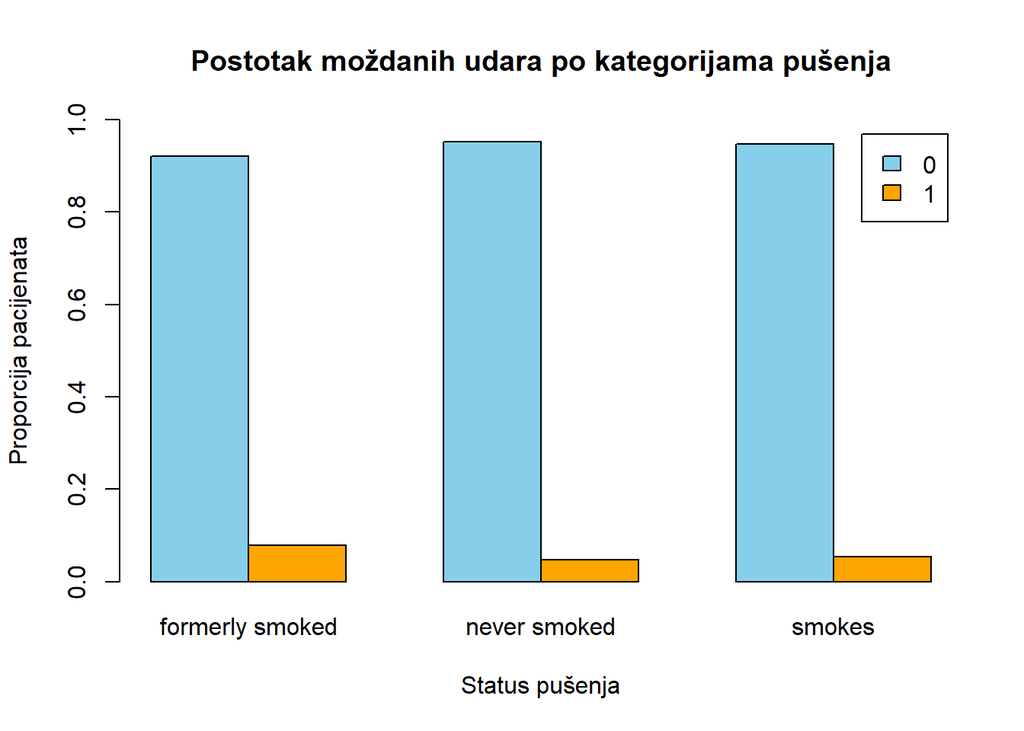

```r
# Proporcije moždanih udara unutar svake kategorije pušenja
# Redovi: status pušenja, stupci: stroke (0/1)
data$smoking_status <- as.factor(data$smoking_status)
data$stroke <- as.factor(data$stroke)

tablica <- table(data$smoking_status, data$stroke)
tablica <- tablica[-4, ]  # uklanjamo 'Unknown'

prop_tab <- prop.table(tablica, 1)  # row-wise proportions

# Barplot – prikaz proporcija
barplot(t(prop_tab),
        beside = TRUE,                  # stupci jedan do drugog
        legend = TRUE,                  # legenda za stroke 0/1
        col = c("skyblue", "orange"),   # boje za stroke 0 i 1
        main = "Postotak moždanih udara po kategorijama pušenja",
        xlab = "Status pušenja",
        ylab = "Proporcija pacijenata",
        ylim = c(0,1))                  # proporcija od 0 do 1
```

## Chi-kvadrat test – osnovna tablica

U ovom dijelu analiziramo odnos između statusa pušenja i pojave moždanog udara. Nakon čišćenja podataka kreirana je kontingencijska tablica koja uključuje tri kategorije pušenja: never smoked, formerly smoked i smokes (kategorija Unknown je uklonjena).

Na temelju ove tablice proveden je Chi-kvadrat test neovisnosti kako bi se provjerilo postoji li statistički značajna povezanost između statusa pušenja i moždanog udara. Test vraća vrijednost statistike, stupnjeve slobode i p-vrijednost. Ako je p-vrijednost manja od 0.05, odbacujemo hipotezu o neovisnosti i zaključujemo da je status pušenja povezan s pojavom moždanog udara.

Uz to se pregledavaju i očekivane frekvencije kako bismo provjerili jesu li zadovoljeni uvjeti za ispravno provođenje Chi-kvadrat testa (svaka očekivana frekvencija > 5). Ovaj test pruža osnovni uvid u to razlikuju li se skupine pušača u učestalosti moždanog udara.

Hipoteze:

- H0: Status pušenja nije povezan s pojavom moždanog udara (neovisne su varijable).
- H1: Status pušenja je povezan s pojavom moždanog udara (varijable nisu neovisne).

```r
# Čišćenje: pretvaranje smoking_status u faktor
data$smoking_status <- as.factor(data$smoking_status)
data$stroke <- as.factor(data$stroke)

# Kontingencijska tablica
tablica <- table(data$smoking_status, data$stroke)
tablica <- tablica[-4, ]
tablica
```

```
##
##                      0    1
##   formerly smoked  815   70
##   never smoked    1802   90
##   smokes           747   42
```

```r
# Chi-square test
chi_rezultat <- chisq.test(tablica)
chi_rezultat
```

```
##
##  Pearson's Chi-squared test
##
## data:  tablica
## X-squared = 11.436, df = 2, p-value = 0.003285
```

```r
chi_rezultat$expected
```

```
##
##                           0         1
##   formerly smoked  834.8682  50.13180
##   never smoked    1784.8256 107.17443
##   smokes           744.3062  44.69377
```

U nastavku je prikazan barplot koji vizualno predstavlja povezanost između statusa pušenja i pojave moždanog udara. Svaka skupina pušačkog statusa (never smoked, formerly smoked, smokes) prikazana je s pripadnim brojem osoba koje su doživjele ili nisu doživjele moždani udar.

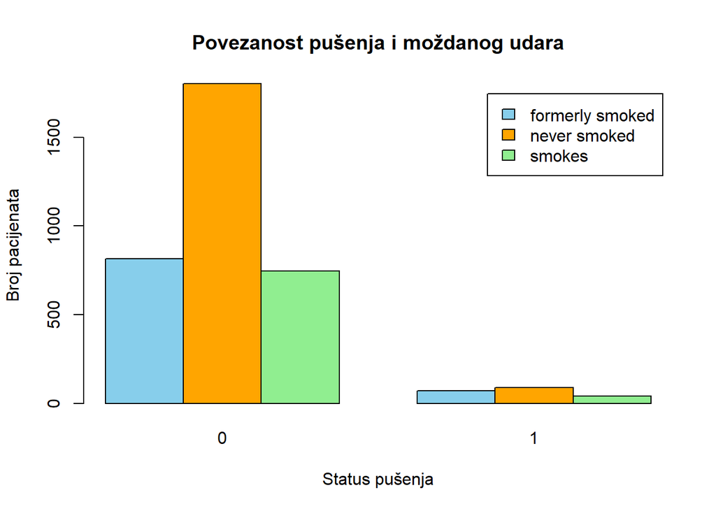

```r
# Barplot – odnos pušenja i moždanog udara (osnovna tablica)
barplot(tablica,
        beside = TRUE,
        legend = TRUE,
        col = c("skyblue", "orange", "lightgreen"),
        main = "Povezanost pušenja i moždanog udara",
        xlab = "Status pušenja",
        ylab = "Broj pacijenata")
```

Kontingencijska tablica uključivala je tri kategorije pušenja: never smoked, formerly smoked i smokes. Chi-kvadrat test neovisnosti pokazao je p-vrijednost manju od 0.05, što znači da postoji statistički značajna povezanost između statusa pušenja i moždanog udara. Očekivane frekvencije su bile zadovoljavajuće (>5), što potvrđuje valjanost testa.

## Spajanje kategorija – bivši i sadašnji pušači vs. nikad pušili

Nakon formiranja nove tablice provodi se Chi-kvadrat test neovisnosti kako bi se provjerilo razlikuje li se učestalost moždanog udara između ove dvije skupine. Ako je dobivena p-vrijednost statistički značajna (p < 0.05), zaključujemo da postoji povezanost između povijesti pušenja i rizika moždanog udara.

Uz test izrađen je i barplot koji grafički prikazuje raspodjelu moždanog udara u dvjema skupinama. Vizualizacija dodatno olakšava uočavanje eventualnih razlika između osoba koje nikad nisu pušile i onih koje su pušile barem jednom u životu.

Hipoteze:

- H0: Povijest pušenja (nikad vs. ikad) nije povezana s pojavom moždanog udara.
- H1: Povijest pušenja (nikad vs. ikad) jest povezana s pojavom moždanog udara.

```r
# Kreiranje nove tablice: spajamo kategorije 'formerly smoked' i 'smokes'
nova_tablica <- table(data$smoking_status, data$stroke)

# Uklanjamo kategoriju 'Unknown' jer nema korisne informacije
nova_tablica <- nova_tablica[-4, ]

# Spajamo redove: formerly smoked + smokes
# (to znači da gledamo osobe koje su ikada pušile – trenutno ili ranije)
nova_tablica[2,] <- nova_tablica[2, ] + nova_tablica[3, ]

# Brišemo sada već spojen treći red
nova_tablica <- nova_tablica[-3, ]

# Preimenujemo redove radi jasnijeg prikaza
rownames(nova_tablica)[1] <- "never smoked"        # nikad nisu pušili
rownames(nova_tablica)[2] <- "was smoking/smokes"  # ikad pušili (prije ili sada)

# Prikaz nove tablice nakon spajanja
nova_tablica
```

```
##
##                         0    1
##   never smoked        815   70
##   was smoking/smokes 2549  132
```

```r
# Chi-kvadrat test za provjeru povezanosti između pušenja (nikad vs. ikad) i moždanog udara
# Ako je p-vrijednost < 0.05 → postoji statistička povezanost između pušenja i moždanog udara
chi_rezultat <- chisq.test(nova_tablica)

# Ispis rezultata testa
chi_rezultat
```

```
##
##  Pearson's Chi-squared test with Yates' continuity correction
##
## data:  nova_tablica
## X-squared = 10.551, df = 1, p-value = 0.001162
```

```r
chi_rezultat$expected
```

```
##
##                              0        1
##   never smoked        834.8682  50.1318
##   was smoking/smokes 2529.1318 151.8682
```

[figure not shown]

```r
barplot(nova_tablica,
        beside = TRUE,
        legend = TRUE,
        col = c("orange", "lightgreen"),
        main = "Moždani udar prema povijesti pušenja",
        xlab = "Status pušenja",
        ylab = "Broj pacijenata")
```